# Práctica 3: Introducción a glmnet

Erick Navarro

2025-07-09

¡Hola! En esta práctica vamos a aprender a usar la librería `glmnet` para realizar modelos de regularización. Utilizaremos un modelo muy sencillo con utilizando el ejemplo que viene en la documentación de la función.

El primer paso es cargar la libraría

```r
#install.packages("glmnet")
library(glmnet)
#install.packages("caret")
library(caret)
```

Ahora haremos un modelo muy simple con la función `glmnet`. Este paquete ajusta modelos de regularización a los datos. Realizaremos un modelo con LASSO, otro con Ridge regression, y otro con Elastic Net.

Después de cargar los datos, generaremos una matriz de datos con predictores, y un vector que corresponda a la variable de respuesta que queremos predecir.

```r
set.seed(1)
x = matrix(rnorm(100 * 20), 100, 20) # Muestrear una matriz de 20x100 a partir de una distribucion normal con media de 0 y SD de 1.
head(x) #Observar la estructura de los datos
```

```
##            [,1]        [,2]       [,3]       [,4]       [,5]        [,6]
## [1,] -0.6264538 -0.62036668  0.4094018  0.8936737  1.0744410  0.07730312
## [2,]  0.1836433  0.04211587  1.6888733 -1.0472981  1.8956548 -0.29686864
## [3,] -0.8356286 -0.91092165  1.5865884  1.9713374 -0.6029973 -1.18324224
## [4,]  1.5952808  0.15802877 -0.3309078 -0.3836321 -0.3908678  0.01129269
## [5,]  0.3295078 -0.65458464 -2.2852355  1.6541453 -0.4162220  0.99160104
## [6,] -0.8204684  1.76728727  2.4976616  1.5122127 -0.3756574  1.59396745
##            [,7]        [,8]        [,9]      [,10]       [,11]      [,12]
## [1,] -0.3410670 -0.70756823 -1.08690882 -1.5414026  1.13496509  0.2418959
## [2,]  1.5024245  1.97157201 -1.82608301  0.1943211  1.11193185 -1.1327594
## [3,]  0.5283077 -0.08999868  0.99528181  0.2644225 -0.87077763  1.4899074
## [4,]  0.5421914 -0.01401725 -0.01186178 -1.1187352  0.21073159 -0.2482471
## [5,] -0.1366734 -1.12345694 -0.59962839  0.6509530  0.06939565  0.1835837
## [6,] -1.1367339 -1.34413012 -0.17794799 -1.0329002 -1.66264885  0.4048710
##           [,13]      [,14]      [,15]      [,16]       [,17]      [,18]
## [1,] -1.5570357  0.3412484  1.5468813  0.8500435  0.34419403  1.6212029
## [2,]  1.9231637  1.3161672  0.1789210 -0.9253130  0.01271984 -0.3291028
## [3,] -1.8568296 -0.9597765 -0.2825466  0.8935812 -0.87345013 -2.3264095
## [4,] -2.1061184 -1.2055752 -0.7672988 -0.9410097  0.34280028  2.1929980
## [5,]  0.6976485  1.5675731 -0.5764042  0.5389521 -0.17738775 -1.0824800
## [6,]  0.9074444  0.2252858 -0.9148558 -0.1819744  0.92143325 -0.5063610
##           [,19]       [,20]
## [1,]  0.7140855 -0.57099429
## [2,]  0.5813846  0.28653902
## [3,] -0.1467239  1.14761986
## [4,]  1.5069818  0.13955870
## [5,] -0.2795326  0.08892661
## [6,]  2.0277387 -2.63015932
```

```r
y = rnorm(100) #Muestrear un vector de 100 elementos a partir de una distribucion normal con media de 0 y SD de 1.
head(y) #Observar la estructura de los datos
```

```
## [1] -0.88614959 -1.92225490  1.61970074  0.51926990 -0.05584993  0.69641761
```

En este caso, no dividiremos los datos en sets de prueba/test, dado que son simulados y podemos crear más. Pero en caso de hacerlo, en este momento debes de dividir tus datos aleatoriamente y asegurarte de que las respuestas estén similarmente distribuidas. También es buena idea explorar las covariables.

```r
#Ejemplo
train.index <- caret::createDataPartition(dataset$respuesta, p = .8, list=FALSE)

train <- dataset[ train.index,]
valid  <- dataset[-train.index,]
table(train$respuesta)
table(valid$respuesta)
```

## RIDGE

Ahora, ajustaremos los modelos utilizando cross-validation para tunear los hiperparámetros. Empezaremos por la regresión Ridge.

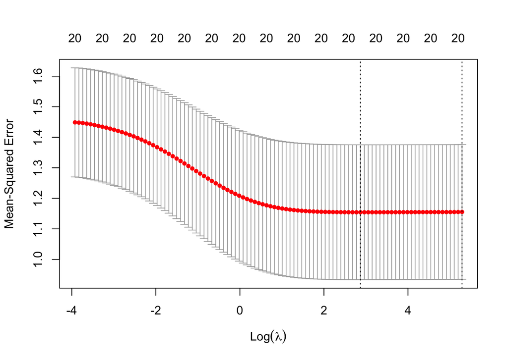

```r
ridge.cv <- cv.glmnet(x,y,alpha=0,family="gaussian",type.measure = "mse", nfolds = 5 )
#plot result
plot(ridge.cv)
```

La función cv.glmnet encuentra el valor de lambda (que regula la función de penalización) que genera el modelo más simple y reduce lo más posible el error del modelo. Es común usar el valor de lambda que se encuentra un error estandar alejado del valor mínimo/óptimo de lambda (lambda.1se). Esto se debe a que el valor genera un modelo un poco más simple, que predice teóricamente igual que el valor de lambda mínimo, y es preferible utilizar el modelo más parsimonioso.

```r
#Ver el valor mínimo de lambda
ridge.cv$lambda.min
```

```
## [1] 17.59017
```

```r
#Escoger el valor de lambda para el modelo
(lambda_RIDGE <- ridge.cv$lambda.1se)
```

```
## [1] 197.5946
```

```r
#Ver los coeficientes
coef(ridge.cv,s=lambda_RIDGE)
```

```
## 21 x 1 sparse Matrix of class "dgCMatrix"
##                        s1
## (Intercept) -1.417928e-01
## V1           1.081303e-37
## V2           1.558850e-37
## V3           1.456894e-37
## V4           7.743916e-38
## V5           1.344299e-38
## V6          -2.383914e-38
## V7          -7.136217e-38
## V8          -1.828085e-37
## V9           4.707007e-38
## V10          4.424868e-38
## V11          1.753737e-38
## V12          4.504213e-38
## V13         -1.378991e-37
## V14         -1.164296e-37
## V15         -3.958688e-38
## V16          2.149861e-38
## V17          1.046798e-37
## V18          4.582848e-38
## V19          6.230532e-38
## V20         -1.977658e-38
```

Ahora hagamos predicciones con base en un conjunto de datos nuevos.

```r
newx = matrix(rnorm(10 * 20), 10, 20)
predict(ridge.cv, newx , s = "lambda.1se", type = "response")  # make predictions
```

```
##       lambda.1se
##  [1,] -0.1417928
##  [2,] -0.1417928
##  [3,] -0.1417928
##  [4,] -0.1417928
##  [5,] -0.1417928
##  [6,] -0.1417928
##  [7,] -0.1417928
##  [8,] -0.1417928
##  [9,] -0.1417928
## [10,] -0.1417928
```

## LASSO Regression

Ahora vamos a ajustar un modelo de LASSO. La diferencia entre LASSO y Ridge es que LASSO puede reducir los coeficientes de algunas variables a cero, lo que significa que elimina esas variables del modelo. Esto es útil para la selección de variables.

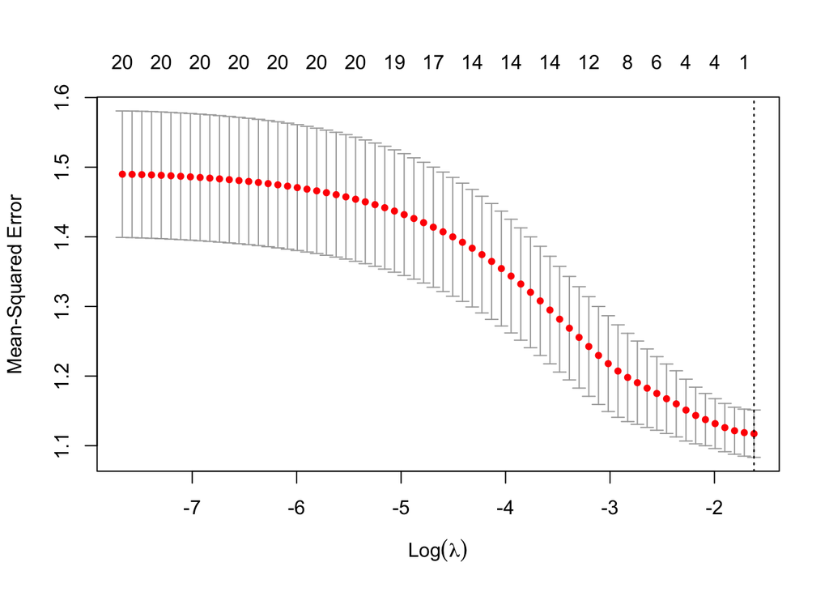

```r
lasso.cv <- cv.glmnet(x,y,alpha=1,family="gaussian",type.measure = "mse", nfolds = 5)
#plot result
plot(lasso.cv)
```

```r
#best value of lambda
lambda_lasso <- lasso.cv$lambda.1se
lambda_lasso
```

```
## [1] 0.1975946
```

```r
#regression coefficients
coef(lasso.cv,s=lambda_lasso)
```

```
## 21 x 1 sparse Matrix of class "dgCMatrix"
##                     s1
## (Intercept) -0.1417928
## V1           .
## V2           .
## V3           .
## V4           .
## V5           .
## V6           .
## V7           .
## V8           .
## V9           .
## V10          .
## V11          .
## V12          .
## V13          .
## V14          .
## V15          .
## V16          .
## V17          .
## V18          .
## V19          .
## V20          .
```

```r
pred_lasso <- predict(lasso.cv, newx, type="response", s=lambda_lasso)

#caret::confusionMatrix(pred_lasso,valid$diabetes)
```

# Elastic Net

Ahora vamos a ajustar un modelo de Elastic Net. Elastic Net es una combinación de LASSO y Ridge.

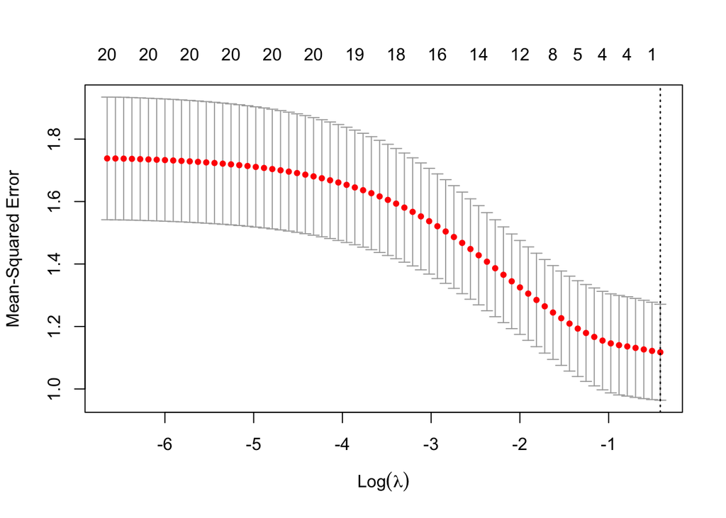

```r
elastic.cv <- cv.glmnet(x,y,alpha=0.3,family="gaussian",type.measure = "mse", nfolds= 5 )
plot(elastic.cv)
```

```r
coef(elastic.cv,s=elastic.cv$lambda.1se)
```

```
## 21 x 1 sparse Matrix of class "dgCMatrix"
##                     s1
## (Intercept) -0.1417928
## V1           .
## V2           .
## V3           .
## V4           .
## V5           .
## V6           .
## V7           .
## V8           .
## V9           .
## V10          .
## V11          .
## V12          .
## V13          .
## V14          .
## V15          .
## V16          .
## V17          .
## V18          .
## V19          .
## V20          .
```

```r
pred_en <- predict(elastic.cv, newx, type="response", s="lambda.1se")

## Caret is good for creating a grid
# model.caretb <- caret::train(y ~ x1 + x2 + x3, data=train, method="glmnet",
#                            family = "gaussian", trControl = fitControl,
#                            tuneGrid = tuneGridb, metric = "ROC")
```